# UB01A3

Anatol

3/20/2022

# Aufgabe 3: Mehrfachregression

```r
states <- data.frame(state.x77)
head(states)
```

|  | Population | Income | Illiteracy | Life.Exp | Murder | HS.Grad | Frost | Area |
| --- | --- | --- | --- | --- | --- | --- | --- | --- |
| Alabama | 3615 | 3624 | 2.1 | 69.05 | 15.1 | 41.3 | 20 | 50708 |
| Alaska | 365 | 6315 | 1.5 | 69.31 | 11.3 | 66.7 | 152 | 566432 |
| Arizona | 2212 | 4530 | 1.8 | 70.55 | 7.8 | 58.1 | 15 | 113417 |
| Arkansas | 2110 | 3378 | 1.9 | 70.66 | 10.1 | 39.9 | 65 | 51945 |
| California | 21198 | 5114 | 1.1 | 71.71 | 10.3 | 62.6 | 20 | 156361 |
| Colorado | 2541 | 4884 | 0.7 | 72.06 | 6.8 | 63.9 | 166 | 103766 |

```r
str(states)
```

```
## 'data.frame':    50 obs. of  8 variables:
##  $ Population: num  3615 365 2212 2110 21198 ...
##  $ Income    : num  3624 6315 4530 3378 5114 ...
##  $ Illiteracy: num  2.1 1.5 1.8 1.9 1.1 0.7 1.1 0.9 1.3 2 ...
##  $ Life.Exp  : num  69 69.3 70.5 70.7 71.7 ...
##  $ Murder    : num  15.1 11.3 7.8 10.1 10.3 6.8 3.1 6.2 10.7 13.9 ...
##  $ HS.Grad   : num  41.3 66.7 58.1 39.9 62.6 63.9 56 54.6 52.6 40.6 ...
##  $ Frost     : num  20 152 15 65 20 166 139 103 11 60 ...
##  $ Area      : num  50708 566432 113417 51945 156361 ...
```

```r
summary(states)
```

```
##    Population        Income       Illiteracy       Life.Exp
##  Min.   :  365   Min.   :3098   Min.   :0.500   Min.   :67.96
##  1st Qu.: 1080   1st Qu.:3993   1st Qu.:0.625   1st Qu.:70.12
##  Median : 2838   Median :4519   Median :0.950   Median :70.67
##  Mean   : 4246   Mean   :4436   Mean   :1.170   Mean   :70.88
##  3rd Qu.: 4968   3rd Qu.:4814   3rd Qu.:1.575   3rd Qu.:71.89
##  Max.   :21198   Max.   :6315   Max.   :2.800   Max.   :73.60
##      Murder          HS.Grad          Frost             Area
##  Min.   : 1.400   Min.   :37.80   Min.   :  0.00   Min.   :  1049
##  1st Qu.: 4.350   1st Qu.:48.05   1st Qu.: 66.25   1st Qu.: 36985
##  Median : 6.850   Median :53.25   Median :114.50   Median : 54277
##  Mean   : 7.378   Mean   :53.11   Mean   :104.46   Mean   : 70736
##  3rd Qu.:10.675   3rd Qu.:59.15   3rd Qu.:139.75   3rd Qu.: 81163
##  Max.   :15.100   Max.   :67.30   Max.   :188.00   Max.   :566432
```

## 3a)

*Passen Sie zunachst das volle Modell an, d.h. regressieren Sie Life.Exp auf alle im Datensatz vorhandenen restlichen Variablen. Vermeiden Sie bitte den Befehlattach. Wie hoch ist das Bestimmtheitsmaß und das adjustierte Bestimmtheitsmaß?*

```r
multLinRegFull <- lm (Life.Exp ~ ., data = states)
summary(multLinRegFull)
```

```
##
## Call:
## lm(formula = Life.Exp ~ ., data = states)
##
## Residuals:
##      Min       1Q   Median       3Q      Max
## -1.48895 -0.51232 -0.02747  0.57002  1.49447
##
## Coefficients:
##               Estimate Std. Error t value Pr(>|t|)
## (Intercept)  7.094e+01  1.748e+00  40.586  < 2e-16 ***
## Population   5.180e-05  2.919e-05   1.775   0.0832 .
## Income      -2.180e-05  2.444e-04  -0.089   0.9293
## Illiteracy   3.382e-02  3.663e-01   0.092   0.9269
## Murder      -3.011e-01  4.662e-02  -6.459 8.68e-08 ***
## HS.Grad      4.893e-02  2.332e-02   2.098   0.0420 *
## Frost       -5.735e-03  3.143e-03  -1.825   0.0752 .
## Area        -7.383e-08  1.668e-06  -0.044   0.9649
## ---
## Signif. codes:  0 '***' 0.001 '**' 0.01 '*' 0.05 '.' 0.1 ' ' 1
##
## Residual standard error: 0.7448 on 42 degrees of freedom
## Multiple R-squared:  0.7362, Adjusted R-squared:  0.6922
## F-statistic: 16.74 on 7 and 42 DF,  p-value: 2.534e-10
```

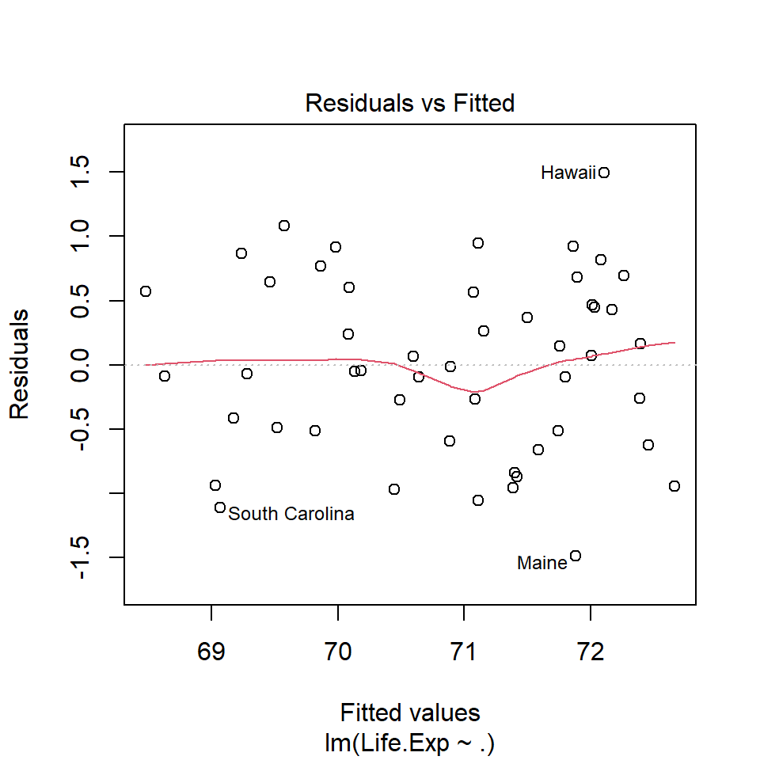

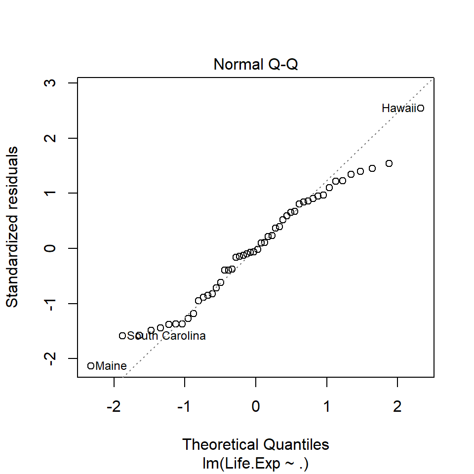

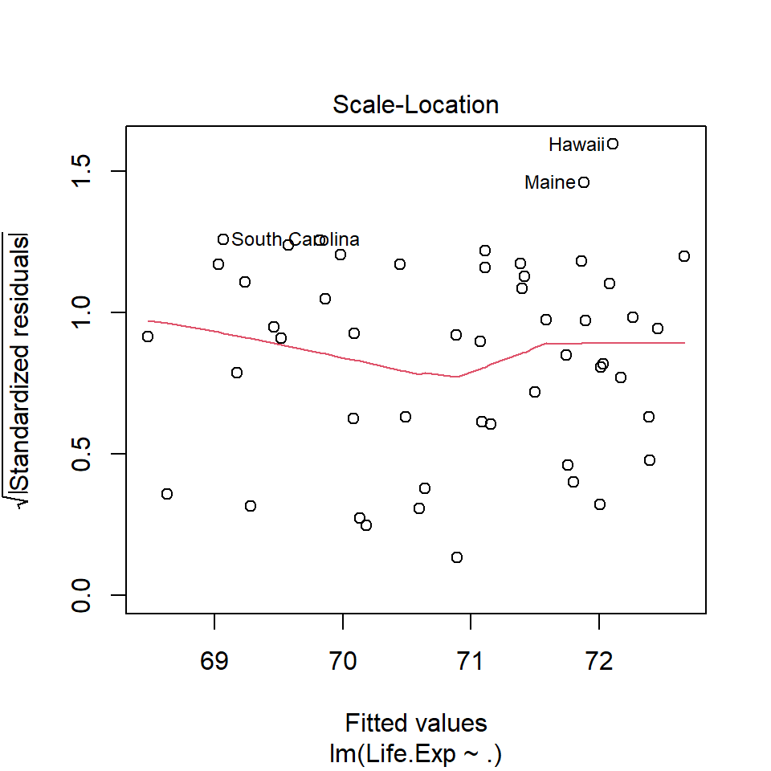

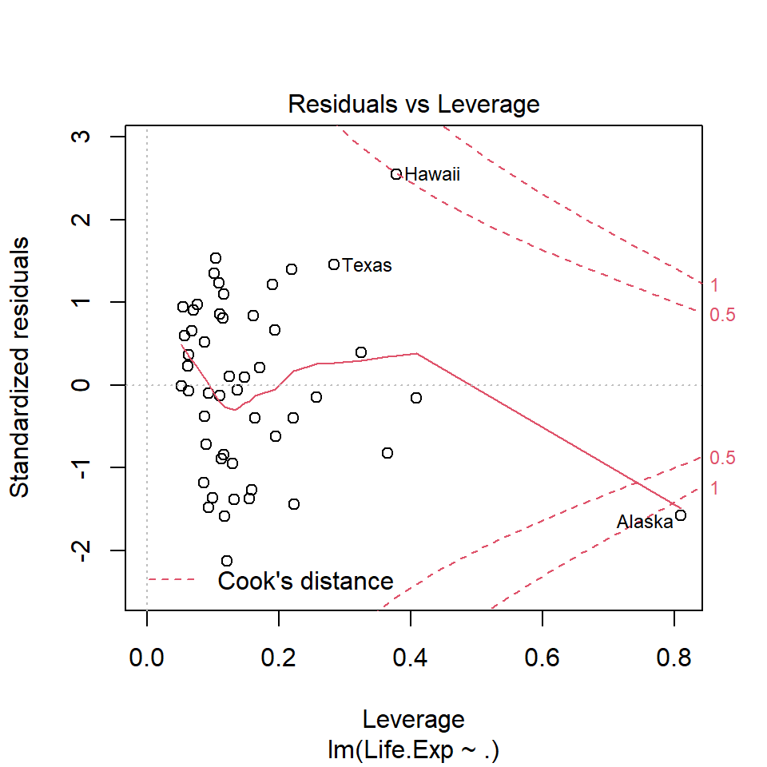

```r
plot(multLinRegFull)
```

```r
summary(multLinRegFull)$r.squared
```

```
## [1] 0.7361563
```

```r
summary(multLinRegFull)$adj.r.squared
```

```
## [1] 0.6921823
```

Bestimmtheitsmaß betragt 0.7362; das adjustierte Bestimmtheitsmaß ist 0.6922.

## 3b)

*Welche der erklrenden Variablen sind zu einem Niveau von α = 0,05 statistisch signiﬁkant? Die hierfur notwendigen Schatzwerte konnen aus dem lm-Objekt mit dem summary-Befehl abgerufen werden. Uber die Funktion qt konnen Sie Quantile fur t-Verteilungen berechnen.*

```r
est <- summary(multLinRegFull)$coefficients[, 1]
se <- summary(multLinRegFull)$coefficients[, 2]
t_val <- est/se
all(t_val == summary(multLinRegFull)$coefficients[, 3])
```

```
## [1] TRUE
```

```r
alpha <- .05
df <- nrow(states) - length(summary(multLinRegFull)$coefficients[, 1])
```

```r
t_krit <-qt(1 - alpha/2, df)
t_test <- abs(t_val) > t_krit
t_test
```

```
## (Intercept)  Population      Income  Illiteracy      Murder     HS.Grad
##        TRUE       FALSE       FALSE       FALSE        TRUE        TRUE
##       Frost        Area
##       FALSE       FALSE
```

Zu einem Niveau von α = 0,05 sind nur Intercept sowie Variablen Murder und HS.Grad signifikant.

## 3c)

*Schauen Sie sich nun die Nullhypothese $β_{Area} = 0$ genauer an. Testen Sie auf zwei verschiedenen Wegen jenseits des einfachen t-Tests, ob die Nullhypothese zu einem Signiﬁkanzniveau von 5% verworfen werden kann. Nutzen Sie dazu die Funktionen confint und pt.*

```r
confint(multLinRegFull, level = .95)["Area",]
```

```
##         2.5 %        97.5 %
## -3.440321e-06  3.292657e-06
```

```r
test_stat <- summary(multLinRegFull)$coefficients["Area", 3]
p_val <- 2*pt(test_stat, df)
p_val < alpha
```

```
## [1] FALSE
```

Da der p-Wert nicht kleiner als $\alpha$ ist, konnen wir die Nullhypothese nicht ablehnen.

## 3d)

*Gehen Sie vom in Teilaufgabe a) geschtzten vollen Modell aus und testen Sie die Nullhypothese $β_{Income} = β_{Illiteracy} = β_{Area} = 0$ gegen die Alternativhypothese ”Mindestens einer dieser Parameter ist ungleich Null.“*

```r
linearHypothesis(multLinRegFull, c("Income=0", "Illiteracy=0", "Area=0"))
```

| Res.Df | RSS | Df | Sum of Sq | F | Pr(>F) |
| --- | --- | --- | --- | --- | --- |
| 45 | 23.30804 | NA | NA | NA | NA |
| 42 | 23.29714 | 3 | 0.0109047 | 0.006553 | 0.9992586 |

```r
multLinRegRest <- lm (Life.Exp ~ Population + Murder + HS.Grad + Frost, data = states)

ssr_unr <- sum(multLinRegFull$residuals^2)
ssr_res <- sum(multLinRegRest$residuals^2)

F_score <- ((ssr_res - ssr_unr)/(length(multLinRegFull$coefficients) - length(multLinRegRest$coefficients)))/(ssr_unr/(nrow(states) - length(multLinRegFull$coefficients)))
F_score
```

```
## [1] 0.00655296
```

```r
qf(.95, 42, 45)
```

```
## [1] 1.652107
```

```r
f_krit <- qf(1 - alpha, 3, df)
F_score > f_krit
```

```
## [1] FALSE
```

```r
anova(multLinRegFull, multLinRegRest)
```

| Res.Df | RSS | Df | Sum of Sq | F | Pr(>F) |
| --- | --- | --- | --- | --- | --- |
| 42 | 23.29714 | NA | NA | NA | NA |
| 45 | 23.30804 | -3 | -0.0109047 | 0.006553 | 0.9992586 |

```r
linearHypothesis(multLinRegFull, hypothesis.matrix =
                   rbind(c(rep(0, 2), 1, rep(0, 5)),
                         c(rep(0, 3), 1, rep(0, 4)),
                         c(rep(0, 7), 1)
                   ),
                 rhs = rep(0, 3)
)
```

| Res.Df | RSS | Df | Sum of Sq | F | Pr(>F) |
| --- | --- | --- | --- | --- | --- |
| 45 | 23.30804 | NA | NA | NA | NA |
| 42 | 23.29714 | 3 | 0.0109047 | 0.006553 | 0.9992586 |

Die Nullhypothese $β_{Income} = β_{Illiteracy} = β_{Area} = 0$ kann zum Signifikanzniveau 5% nicht verworfen werden.

## 3e)

*Testen Sie nun, ob die Koeﬃzienten $β_{Illiteracy} und β_{HS.Grad}$ gleich sind. Nutzen Sie dazu bitte die Funktion linearHypothesis aus dem Paket car.*

```r
linearHypothesis(multLinRegFull, "Illiteracy = HS.Grad")
```

| Res.Df | RSS | Df | Sum of Sq | F | Pr(>F) |
| --- | --- | --- | --- | --- | --- |
| 43 | 23.29814 | NA | NA | NA | NA |
| 42 | 23.29714 | 1 | 0.0010034 | 0.0018089 | 0.9662771 |

```r
linearHypothesis(multLinRegFull,
                 hypothesis.matrix = c(rep(0, 3), 1, 0, -1, rep(0, 2)))
```

| Res.Df | RSS | Df | Sum of Sq | F | Pr(>F) |
| --- | --- | --- | --- | --- | --- |
| 43 | 23.29814 | NA | NA | NA | NA |
| 42 | 23.29714 | 1 | 0.0010034 | 0.0018089 | 0.9662771 |

Die Hypothese, dass die Koeﬃzienten $β_{Illiteracy} und β_{HS.Grad}$ gleich sind, kann zum Signifikanzniveau 5% nicht verworfen werden.

## 3f)

*Berechnen Sie ein Modell in welchem Sie einen Interaktionsterm zwischen der Variable Income und Murder unterstellen.*

```r
multLinRegFullInter <- lm (Life.Exp ~ . + Income*Murder, data = states)
summary(multLinRegFullInter)
```

```
##
## Call:
## lm(formula = Life.Exp ~ . + Income * Murder, data = states)
##
## Residuals:
##      Min       1Q   Median       3Q      Max
## -1.25673 -0.48769  0.06232  0.49667  1.71842
##
## Coefficients:
##                 Estimate Std. Error t value Pr(>|t|)
## (Intercept)    6.705e+01  3.009e+00  22.286   <2e-16 ***
## Population     5.864e-05  2.901e-05   2.021   0.0498 *
## Income         7.778e-04  5.614e-04   1.386   0.1734
## Illiteracy    -1.658e-01  3.816e-01  -0.434   0.6663
## Murder         1.746e-01  3.053e-01   0.572   0.5706
## HS.Grad        5.421e-02  2.317e-02   2.340   0.0242 *
## Frost         -5.295e-03  3.102e-03  -1.707   0.0953 .
## Area           9.769e-07  1.770e-06   0.552   0.5840
## Income:Murder -1.043e-04  6.618e-05  -1.576   0.1227
## ---
## Signif. codes:  0 '***' 0.001 '**' 0.01 '*' 0.05 '.' 0.1 ' ' 1
##
## Residual standard error: 0.732 on 41 degrees of freedom
## Multiple R-squared:  0.7512, Adjusted R-squared:  0.7027
## F-statistic: 15.48 on 8 and 41 DF,  p-value: 3.46e-10
```

# Aufgabe 4: Dummy-Variablen

*Laden Sie den Prestige Datensatz aus der Aufgabe 1 nochmals ein und entfernen Sie die fehlenden Werte. Erstellen Sie dann ein multiples Regressionsmodell unter Verwendung der typen Variable. Wie sind die Variablen zu interpretieren, und was ist bei der Interpretation von Dummyvariablen zu beachten?*

```r
Prestige
```

[output not shown]

[output cut: 72 more lines]

```r
prest_data <- na.omit(Prestige)
multLinRegPrest <- lm(prestige ~ education + income + women + type, data = prest_data)
summary(multLinRegPrest)
```

```
##
## Call:
## lm(formula = prestige ~ education + income + women + type, data = prest_data)
##
## Residuals:
##      Min       1Q   Median       3Q      Max
## -14.7485  -4.4817   0.3119   5.2478  18.4978
##
## Coefficients:
##               Estimate Std. Error t value Pr(>|t|)
## (Intercept) -0.8139032  5.3311558  -0.153 0.878994
## education    3.6623557  0.6458300   5.671 1.63e-07 ***
## income       0.0010428  0.0002623   3.976 0.000139 ***
## women        0.0064434  0.0303781   0.212 0.832494
## typeprof     5.9051970  3.9377001   1.500 0.137127
## typewc      -2.9170720  2.6653961  -1.094 0.276626
## ---
## Signif. codes:  0 '***' 0.001 '**' 0.01 '*' 0.05 '.' 0.1 ' ' 1
##
## Residual standard error: 7.132 on 92 degrees of freedom
## Multiple R-squared:  0.8349, Adjusted R-squared:  0.826
## F-statistic: 93.07 on 5 and 92 DF,  p-value: < 2.2e-16
```

Professionelle haben c.p. um 5.9 mehr Prestigepunkte als Blue-Collar-Arbeiter. White-Collar-Worker haben c.p. um 2.9 weniger Prestigepunkte als Blue-Collar-Arbeiter. Bei der Interpretation von Dummyvariablen ist die Referenzkategorie zu beachten.